# Study on the Benefits of Personal Emails in Online and Classroom Teaching

# Data Description

## Data Preparation

```r
library(dplyr)
library(knitr)
library(apa)
library(psych)
library(rcompanion)
library(ggplot2)
```

With this cell, we

1. read data
2. exclude students with less than 10 events over the whole semester
3. add columns for the event types indicating activity (TRUE if any event or FALSE if none)

```r
eirbs_data_raw <- read.csv("data/csv_dataset.csv", sep="\t")
eirbs_data <- read.csv("data/csv_dataset.csv", sep="\t")
eirbs_data$exam_result <- replace(eirbs_data$exam_result,
                                  eirbs_data$exam_result == "–", "-")
eirbs_data_sum <- eirbs_data %>% group_by(pid) %>% summarise(all_ct = sum(event_count))
keep_ids <- dplyr::filter(eirbs_data_sum, all_ct >= 10)
notkeep_ids <- dplyr::filter(eirbs_data_sum, all_ct < 10)
notkeep_ids_info <- dplyr::filter(eirbs_data, pid %in% c(notkeep_ids$pid) & week == 1)

data_clean <- dplyr::filter(eirbs_data, pid %in% c(keep_ids$pid))
ct_cols = c('bilateral_communication_count', 'quiz_count', 'booklet_count',
            'arena_count', 'chat_count', 'forum_count',
            'playground_count', 'event_count')
for (col in ct_cols){
  if (col == 'bilateral_communication_count'){
    new_col = 'bilat_count_bool'
  }
  else {
    new_col = paste0(col, "_bool")
  }
  data_clean[new_col] <- if_else(data_clean[[col]] > 0, true=TRUE, false=FALSE)
}
```

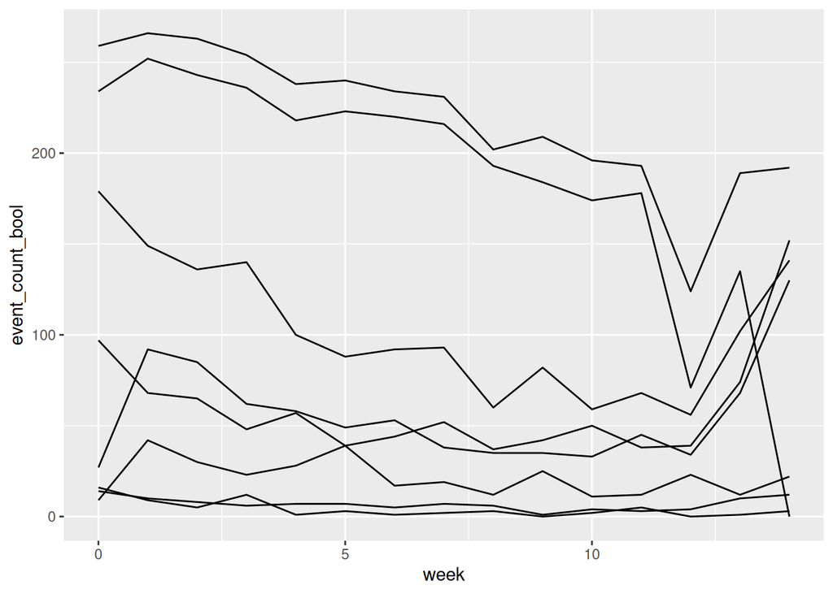

```r
plot_data <- dplyr::filter(data_clean) %>%group_by(week) %>%
  summarise_at(c("event_count_bool", "arena_count_bool", "bilat_count_bool",
                 "booklet_count_bool", "chat_count_bool", "forum_count_bool",
                 "playground_count_bool", "quiz_count_bool"), sum)
ggplot(plot_data, aes(x=week)) + geom_line(aes(y=event_count_bool)) +
  geom_line(aes(y=arena_count_bool)) + geom_line(aes(y=bilat_count_bool)) +
  geom_line(aes(y=booklet_count_bool)) + geom_line(aes(y=chat_count_bool)) +
  geom_line(aes(y=forum_count_bool)) + geom_line(aes(y=playground_count_bool)) +
  geom_line(aes(y=quiz_count_bool))
```

```r
# write.csv(plot_data, "active_events_test_all2.csv", row.names = FALSE)
```

```r
paper_data <- filter(data_clean, week==0) %>% dplyr::select(group, age, gender, birth_country, subgroup, prev_years)
all_grps <- list(c("A", "B", "C"), "A", "B", "C")
for (grp in all_grps){
  print(grp)
  paper_data_ct <- paper_data %>% filter(group %in%  grp)
  my_ca <- count(paper_data_ct, age) %>% mutate(ratio = round(100*(n/sum(n)), digits = 0))
  py_ca <- count(paper_data_ct, prev_years)  %>% mutate(ratio = round(100*(n/sum(n)), digits = 0))
  sg_ca <- count(paper_data_ct, subgroup)  %>% mutate(ratio = round(100*(n/sum(n)), digits = 0))
  bc_ca <- count(paper_data_ct, birth_country)  %>% mutate(ratio = round(100*(n/sum(n)), digits = 0))
  gen_ca <- count(paper_data_ct, gender)  %>% mutate(ratio = round(100*(n/sum(n)), digits = 0))


  print(my_ca)
  print(gen_ca)
  print(bc_ca)
  print(sg_ca)
  print(py_ca)
}
```

```
## [1] "A" "B" "C"
##       age   n ratio
## 1  [0-19]  24     9
## 2 [20-29] 221    78
## 3   [30+]  37    13
##   gender   n ratio
## 1      f  93    33
## 2      m 189    67
##   birth_country   n ratio
## 1        D-A-CH 209    74
## 2         other  73    26
##   subgroup   n ratio
## 1        f 145    51
## 2        m 137    49
##   prev_years   n ratio
```

[output cut: 53 more lines]

## Active Students in the Groups

### All Events

```r
# data frame for result
exp_weeks_all <- c(1, 2, 3, 4, 5, 6, 7, 8, 9, 10, 11, 12)
result_df_all <- data.frame(week = exp_weeks_all)
single_grps <- list("A", "B", "C")
for (grp in single_grps){
  grp_values_all <- numeric()
  for (wk in exp_weeks_all){
    value_tab <- nrow(data_clean %>% filter(event_count > 0 & group == grp & week==wk))
    grp_members <- nrow(data_clean %>% filter(group == grp & week==wk))
    grp_values_all <- c(grp_values_all, round(value_tab / grp_members, digits = 2))
  }
  result_df_all <- cbind(result_df_all, grp_values_all)

}
colnames(result_df_all) <- c("Week", single_grps)
print(result_df_all)
```

```
##    Week    A    B    C
## 1     1 0.93 0.98 0.92
## 2     2 0.94 0.98 0.88
## 3     3 0.90 0.91 0.89
## 4     4 0.85 0.89 0.80
## 5     5 0.79 0.91 0.86
## 6     6 0.83 0.88 0.78
## 7     7 0.77 0.82 0.87
## 8     8 0.68 0.79 0.69
## 9     9 0.72 0.72 0.78
## 10   10 0.71 0.74 0.63
## 11   11 0.64 0.73 0.69
## 12   12 0.41 0.42 0.49
```

### Only Direct Communication

```r
# data frame for result
exp_weeks_dc <- c(1, 2, 3, 4, 5, 6, 7, 8, 9, 10, 11, 12)
result_df_dc <- data.frame(week = exp_weeks_dc)
single_grps <- list("A", "B", "C")
for (grp in single_grps){
  grp_values_dc <- numeric()
  for (wk in exp_weeks_dc){
    value_tab <- nrow(data_clean %>% filter(bilateral_communication_count > 0 & group == grp & week==wk))
    grp_members <- nrow(data_clean %>% filter(group == grp & week==wk))
    grp_values_dc <- c(grp_values_dc, round(value_tab / grp_members, digits = 2))
  }
  result_df_dc <- cbind(result_df_dc, grp_values_dc)

}
colnames(result_df_dc) <- c("Week", single_grps)
print(result_df_dc)
```

```
##    Week    A    B    C
## 1     1 0.35 0.03 0.04
## 2     2 0.07 0.20 0.05
## 3     3 0.02 0.10 0.13
## 4     4 0.19 0.06 0.04
## 5     5 0.07 0.31 0.04
## 6     6 0.02 0.08 0.09
## 7     7 0.05 0.11 0.04
## 8     8 0.03 0.07 0.03
## 9     9 0.03 0.03 0.20
## 10   10 0.05 0.03 0.03
## 11   11 0.02 0.07 0.04
## 12   12 0.03 0.01 0.20
```

# Hypothesis Testing

We want to compare two categorical variables and the expected frequencies are all above five. A chi-squared test seems to be the most sensible solution here. We do not apply Yate’s continuity correction. We make us of the **Holm–Bonferroni** procedure for multi-test correction with a significance level of 0.05, i.e., alpha=0.05.

```r
run_chi2 <- function(event_col, w, grps, conf_level, custom_levels){
  chi2_data <- dplyr::filter(data_clean, week==w & group %in% grps)
  # see https://stackoverflow.com/a/50126564
  groups_conting <- table(factor(chi2_data$group, levels=grps),
                          factor(chi2_data[[event_col]], levels=custom_levels))
  print(groups_conting)
  chi2_test <- chisq.test(groups_conting, correct=F)
  cat("\nTest: ", grps, w, "\n")
  cat(chisq_apa(chi2_test, format="text", print_n = TRUE))
  cat("\nP-Value:", chi2_test$p.value)
  if (event_col!="age"){
    cat("\nEffektstärke - Phi:", phi(groups_conting))
  }
  cat("\nCramer's V:", cramerV(groups_conting), "\n")
  return (chi2_test$p.value)
}
```

## H1: Mails increase the activity of students.

For our analysis, we consider only one week at a time. By limiting the analysis to one week, we avoid issues with repeated measurements.

### Personal/Specific E-Mails

In the first week, Group A receives the personal/specific intervention, whereas Group C has not received any intervention so far. With the chi-squared test, we want to find whether there is a relationship between the Group and the activity of the students. For the other personal/specific emails, we apply the same procedure.

```r
p_val_ac_total_gr <- run_chi2("event_count_bool", 1, c("A", "C"), 0.95, c(TRUE, FALSE))
```

```
##
##     TRUE FALSE
##   A   93     7
##   C   86     7
##
## Test:  A C 1
## chi^2(1, n = 193) = 0.02, p = .888
## P-Value: 0.8878639
## Effektstärke - Phi: 0.0101
## Cramer's V: 0.01015
```

```r
p_val_bc_total_gr <- run_chi2("event_count_bool", 5, c("B", "C"), 0.95, c(TRUE, FALSE))
```

```
##
##     TRUE FALSE
##   B   81     8
##   C   80    13
##
## Test:  B C 5
## chi^2(1, n = 182) = 1.11, p = .292
## P-Value: 0.2922317
## Effektstärke - Phi: 0.0781
## Cramer's V: 0.07807
```

```r
p_val_ca_total_gr <- run_chi2("event_count_bool", 9, c("C", "A"), 0.95, c(TRUE, FALSE))
```

```
##
##     TRUE FALSE
##   C   73    20
##   A   72    28
##
## Test:  C A 9
## chi^2(1, n = 193) = 1.09, p = .297
## P-Value: 0.2969648
## Effektstärke - Phi: 0.0751
## Cramer's V: 0.07507
```

Running the chi-squared test we get p-values of 0.8878639, 0.2922317 and 0.2969648. If we apply multi-test correction, we get p-values of 1 for all weeks. Hence, there is no significant effect of the mails.

### Personal/Unspecific E-Mails

In the second week, Group B receives the personal/unspecific intervention, whereas Group C has not received any intervention so far. We apply the same procedure for all personal/unspecific emails.

```r
p_val_bc_total_or <- run_chi2("event_count_bool", 2, c("B", "C"), 0.95, c(TRUE, FALSE))
```

```
##
##     TRUE FALSE
##   B   87     2
##   C   82    11
##
## Test:  B C 2
## chi^2(1, n = 182) = 6.29, p = .012
## P-Value: 0.01211592
## Effektstärke - Phi: 0.186
## Cramer's V: 0.186
```

```r
p_val_ab_total_or <- run_chi2("event_count_bool", 4, c("A", "B"), 0.95, c(TRUE, FALSE))
```

```
##
##     TRUE FALSE
##   A   85    15
##   B   79    10
##
## Test:  A B 4
## chi^2(1, n = 189) = 0.58, p = .446
## P-Value: 0.4458151
## Effektstärke - Phi: -0.0555
## Cramer's V: 0.05546
```

```r
p_val_ca_total_or <- run_chi2("event_count_bool", 12, c("C", "A"), 0.95, c(TRUE, FALSE))
```

```
##
##     TRUE FALSE
##   C   46    47
##   A   41    59
##
## Test:  C A 12
## chi^2(1, n = 193) = 1.39, p = .238
## P-Value: 0.2377654
## Effektstärke - Phi: 0.085
## Cramer's V: 0.08498
```

Running the chi-squared test we get a p-value of 0.0121159, 0.4458151 and 0.2377654. If we apply multi-test correction, we get p-values of 0.08 and 1 for the other two interventions. Hence, there is no significant effect of the mails.

## H2: Mails increase the communication between students and tutors.

### Personal/Specific E-Mails

Same as above but we look only at the bilateral communication.

```r
p_val_ac_mail_gr <- run_chi2("bilat_count_bool", 1, c("A", "C"), 0.95, c(TRUE, FALSE))
```

```
##
##     TRUE FALSE
##   A   35    65
##   C    4    89
##
## Test:  A C 1
## chi^2(1, n = 193) = 28.16, p < .001
## P-Value: 1.114327e-07
## Effektstärke - Phi: 0.382
## Cramer's V: 0.382
```

```r
p_val_bc_mail_gr <- run_chi2("bilat_count_bool", 5, c("B", "C"), 0.95, c(TRUE, FALSE))
```

```
##
##     TRUE FALSE
##   B   28    61
##   C    4    89
##
## Test:  B C 5
## chi^2(1, n = 182) = 23.15, p < .001
## P-Value: 1.498481e-06
## Effektstärke - Phi: 0.357
## Cramer's V: 0.3566
```

```r
p_val_ca_mail_gr <- run_chi2("bilat_count_bool", 9, c("C", "A"), 0.95, c(TRUE, FALSE))
```

```
##
##     TRUE FALSE
##   C   19    74
##   A    3    97
##
## Test:  C A 9
## chi^2(1, n = 193) = 14.50, p < .001
## P-Value: 0.0001405236
## Effektstärke - Phi: 0.274
## Cramer's V: 0.2741
```

Running the chi-squared test we get a p-value of 1.1143267^{-7}, 1.4984813^{-6} and 1.4052364^{-4}. If we apply multi-test correction, we get p-values of 1.448625e-06, 1.798178e-05 and 1.545760e-03. Hence, there is a significant effect of the mails.

### Personal/Unspecific E-Mails

Same as above but we look only at the bilateral communication.

```r
p_val_bc_mail_or <- run_chi2("bilat_count_bool", 2, c("B", "C"), 0.95, c(TRUE, FALSE))
```

```
##
##     TRUE FALSE
##   B   18    71
##   C    5    88
##
## Test:  B C 2
## chi^2(1, n = 182) = 9.08, p = .003
## P-Value: 0.002581502
## Effektstärke - Phi: 0.223
## Cramer's V: 0.2234
```

```r
p_val_ab_mail_or <- run_chi2("bilat_count_bool", 4, c("A", "B"), 0.95, c(TRUE, FALSE))
```

```
##
##     TRUE FALSE
##   A   19    81
##   B    5    84
##
## Test:  A B 4
## chi^2(1, n = 189) = 7.61, p = .006
## P-Value: 0.005814964
## Effektstärke - Phi: 0.201
## Cramer's V: 0.2006
```

```r
p_val_ca_mail_or <- run_chi2("bilat_count_bool", 12, c("C", "A"), 0.95, c(TRUE, FALSE))
```

```
##
##     TRUE FALSE
##   C   19    74
##   A    3    97
##
## Test:  C A 12
## chi^2(1, n = 193) = 14.50, p < .001
## P-Value: 0.0001405236
## Effektstärke - Phi: 0.274
## Cramer's V: 0.2741
```

Running the chi-squared test we get a p-value of 0.0025815, 0.005815, 1.4052364^{-4}. If we apply multi-test correction, we get p-values of 2.323351e-02, 4.651971e-02 and 1.545760e-03. Hence, there is a significant effect of the mails.

## H3: Females are more active if contacted by a female tutor.

Here, we test whether females are more active if they are contacted by tutors of the same gender. For that, we determine the number of active days for each female student and compare the mean of two groups of female students, here contacted by a female tutor vs. contacted by a male tutor. We make use of the Welch t-test as this test is robust regarding its assumptions.

### Female Students / Only direct communication

Here, we test whether females like to contact a female tutor more than a male tutor. That is, we consider bilateral communication.

```r
data_female2 <- dplyr::filter(data_clean, gender=="f" & subgroup=="f" & week <= 12 & week > 0) %>%
  group_by(pid) %>% summarise(sum_active_days = sum(bilateral_communication_active_days))

data_male2 <- dplyr::filter(data_clean, gender=="f" & subgroup=="m" & week <=12 & week > 0) %>%
  group_by(pid) %>% summarise(sum_active_days = sum(bilateral_communication_active_days))

t_fm_direct <- t.test(data_female2$sum_active_days, data_male2$sum_active_days,
                      alternative = "two.sided", var.equal = FALSE)

t_fm_direct
```

```
##
##  Welch Two Sample t-test
##
## data:  data_female2$sum_active_days and data_male2$sum_active_days
## t = -1.2988, df = 46.733, p-value = 0.2004
## alternative hypothesis: true difference in means is not equal to 0
## 95 percent confidence interval:
##  -3.1746093  0.6838857
## sample estimates:
## mean of x mean of y
## 0.9591837 2.2045455
```

```r
cat("SD Tutorin", sd(data_female2$sum_active_days))
```

```
## SD Tutorin 1.368685
```

```r
cat("SD Tutor", sd(data_male2$sum_active_days))
```

```
## SD Tutor 6.226648
```

We get a p-value of 0.200382. With multi-test correction, this corresponds to 1, which is above our significance level. So there is no difference between those two groups.

## Mutli-Test Correction

We make us of the **Holm–Bonferroni** procedure for multi-test correction.

```r
options(scipen=3)
all_ps <- c(w1ps_all=p_val_ac_total_gr, w5ps_all=p_val_bc_total_gr, w9ps_all=p_val_ca_total_gr,
            w2us_all=p_val_bc_total_or, w4us_all=p_val_ab_total_or, w12us_all=p_val_ca_total_or,
            w1ps_mail=p_val_ac_mail_gr, w5ps_mail=p_val_bc_mail_gr, w9ps_mail=p_val_ca_mail_gr,
            w2us_mail=p_val_bc_mail_or, w4us_mail=p_val_ab_mail_or, w12us_mail=p_val_ca_mail_or,
            t_test=t_fm_direct$p.value)
corrected_p <- p.adjust(all_ps, method = "holm")
corrected_p_df <- data.frame(p_value = all_ps, adjusted_p = corrected_p)
print(corrected_p_df)
```

```
##                    p_value     adjusted_p
## w1ps_all   0.8878638855339 1.000000000000
## w5ps_all   0.2922317454136 1.000000000000
## w9ps_all   0.2969647650614 1.000000000000
## w2us_all   0.0121159219689 0.084811453782
## w4us_all   0.4458151371265 1.000000000000
## w12us_all  0.2377653643647 1.000000000000
## w1ps_mail  0.0000001114327 0.000001448625
## w5ps_mail  0.0000014984813 0.000017981776
## w9ps_mail  0.0001405236419 0.001545760061
## w2us_mail  0.0025815016058 0.023233514452
## w4us_mail  0.0058149639149 0.046519711319
## w12us_mail 0.0001405236419 0.001545760061
## t_test     0.2003819605735 1.000000000000
```

```r
options(scipen=0)
```

# Presence data

```r
eirbs_data_raw_presence<- read.csv("data/csv_dataset_presence.csv", sep="\t")
eirbs_data_presence <- read.csv("data/csv_dataset_presence.csv", sep="\t")

ct_cols = c('bilateral_communication_count')
for (col in ct_cols){
  if (col == 'bilateral_communication_count'){
    new_col = 'bilat_count_bool'
  }
  eirbs_data_presence[new_col] <- if_else(eirbs_data_presence[[col]] > 0,
                                          true=TRUE, false=FALSE)
}

# data frame for result
exp_weeks <- c(1, 2, 3, 4, 5, 6, 7, 8, 9, 10)
result_df <- data.frame(week = exp_weeks)
single_grps <- list("A", "B", "C", "D")

# calculate activity for each group
for (grp in single_grps){
  grp_values <- numeric()
  for (wk in exp_weeks){
    value_tab <- nrow(eirbs_data_presence %>% filter(
      bilateral_communication_count > 0 & group == grp & week==wk))
    grp_members <- nrow(eirbs_data_presence %>% filter(group == grp & week==wk))
    grp_values <- c(grp_values, round(value_tab / grp_members, digits = 3))
  }
  result_df <- cbind(result_df, grp_values)
}
colnames(result_df) <- c("Week", single_grps)
print(result_df)
```

```
##    Week     A     B     C     D
## 1     1 0.124 0.135 0.144 0.135
## 2     2 0.019 0.019 0.048 0.000
## 3     3 0.000 0.029 0.010 0.058
## 4     4 0.057 0.125 0.077 0.125
## 5     5 0.019 0.029 0.010 0.019
## 6     6 0.010 0.019 0.019 0.010
## 7     7 0.048 0.077 0.067 0.077
## 8     8 0.029 0.048 0.029 0.010
## 9     9 0.019 0.067 0.019 0.029
## 10   10 0.057 0.087 0.154 0.058
```